# IE360 Project Report

## Group 10

### ----------------------------------

### Raşit Cem Solatay 2018402072

### Batuhan Sarıtaş 2018402153

### Gabriel Erin Liakof 2018402177

# Introduction

#### In this project, main goal is to predict hourly solar power predictions of KIVANC 2 GES (a solar power plant in Mersin) starting from May 25 to June 3, 2022. Past hourly production data ranging from February 1, 2021 to two days before the current date are provided and updated each day. Thus, prediction is made in a very similar setting to the real life dynamics of energy markets. On day d, production up until day d-2 are given, and prediction is provided for day d+1.

#### In addition to the production data, weather information is provided for 9 different locations. These locations constitute adjacent grid points around the plant and their coordinates range from 36.25 latitude, 33 longtitude to 36.75 latitude, 33.5 longtitude.

#### For each grid point, past hourly observations of four different weather variables are provided. These variables are;

### TEMP:

#### Temperature at the provided location.

### REL_HUMIDITY:

#### Relative humidity at the provided location. Gives information about rainy or cloudy weather.

### DSWRF:

#### Stands for downward shortwave radiation flux. An estimate of the total amount of shortwave radiation (both direct and diffuse) that reaches the Earth's surface.

#### CLOUD_LOW_LAYER:

#### Total cloud cover data for low-level type of clouds.

#### Our starting point is to merge the weather and production data after format corrections. After then, we will construct time series regressive models on the past productions to predict future productions.

### Locations and weather variables

#### Weather information of 9 different grid points does not present practical information since, when used distinctly, locations cover huge areas compared to the plant's size, and information such as cloudiness, temperature, or dwrf are highly correlated with one another at this level. Thus, instead of continuing with 9 locations, averages of each variable are computed for further investigation.

```r
wide_weather <- data.table(wide_weather, key = "datetime")
dt <- merge.data.table(wide_weather, production, all.x = TRUE, by="datetime")
dt[, date.y := NULL]
dt[, hour.y := NULL]
colnames(dt)[2] <- "date"
colnames(dt)[3] <- "hour"

dt[, CLL := rowMeans(dt[,4:12], na.rm=TRUE)]
dt[, DSWRF := rowMeans(dt[,13:21], na.rm=TRUE)]
dt[, RELH := rowMeans(dt[,22:30], na.rm=TRUE)]
dt[, TEMP := rowMeans(dt[,31:39], na.rm=TRUE)]
dt[, 4:39 := NULL]
```

### Plots for weather variables

#### Time series data are plotted to observe the patterns for each variable.

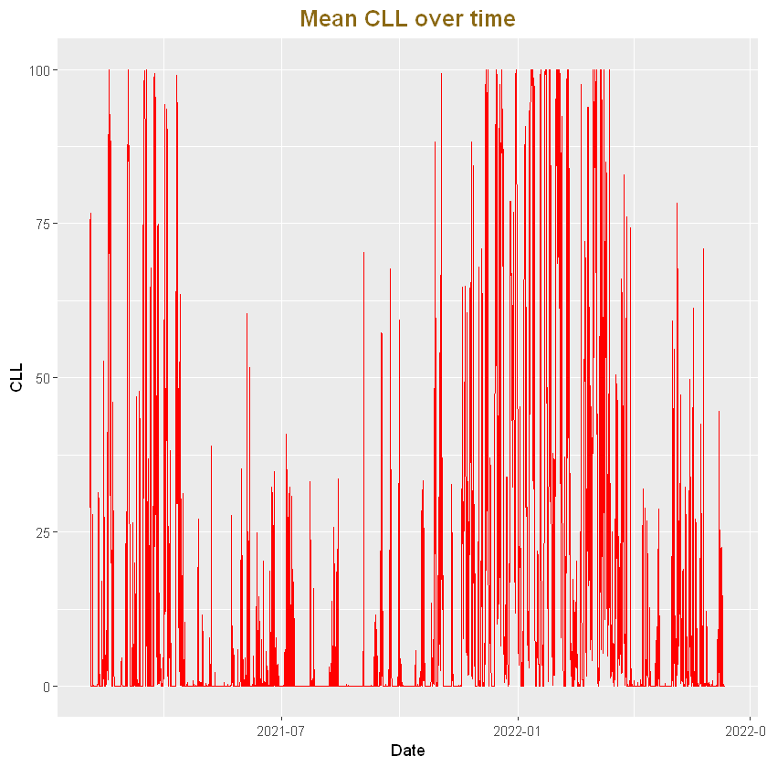

```r
ggplot(dt, aes(x=datetime)) + geom_line(aes(y=CLL), color="red")+
  labs(title = "Mean CLL over time", x = "Date",y = "CLL")+
  theme(plot.title = element_text(color = "goldenrod4", size = 15, face = "bold",hjust=0.5),
  plot.subtitle = element_text(size = 7,color="goldenrod3", face = "bold", hjust = 0.5))
```

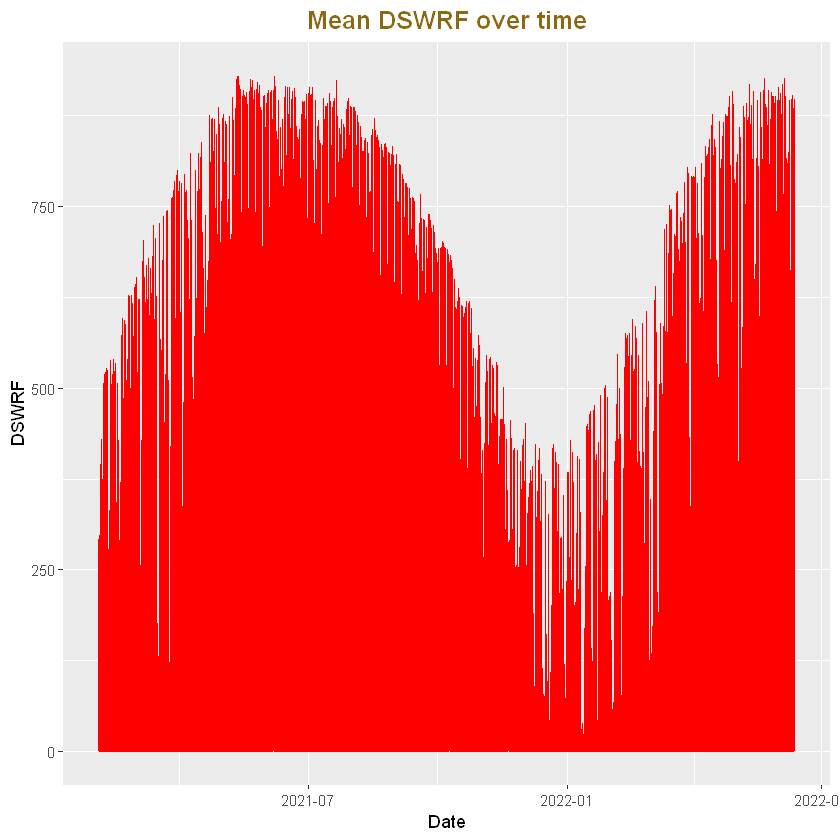

```r
ggplot(dt, aes(x=datetime)) + geom_line(aes(y=DSWRF), color="red")+
  labs(title = "Mean DSWRF over time", x = "Date",y = "DSWRF")+
  theme(plot.title = element_text(color = "goldenrod4", size = 15, face = "bold",hjust=0.5),
  plot.subtitle = element_text(size = 7,color="goldenrod3", face = "bold", hjust = 0.5))
```

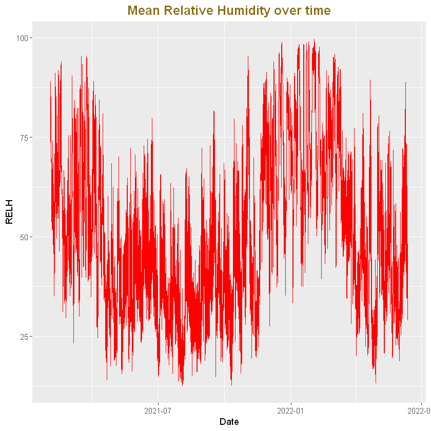

```r
ggplot(dt, aes(x=datetime)) + geom_line(aes(y=RELH), color="red")+
 labs(title = "Mean Relative Humidity over time", x = "Date",y = "RELH")+
  theme(plot.title = element_text(color = "goldenrod4", size = 15, face = "bold",hjust=0.5),
  plot.subtitle = element_text(size = 7,color="goldenrod3", face = "bold", hjust = 0.5))
```

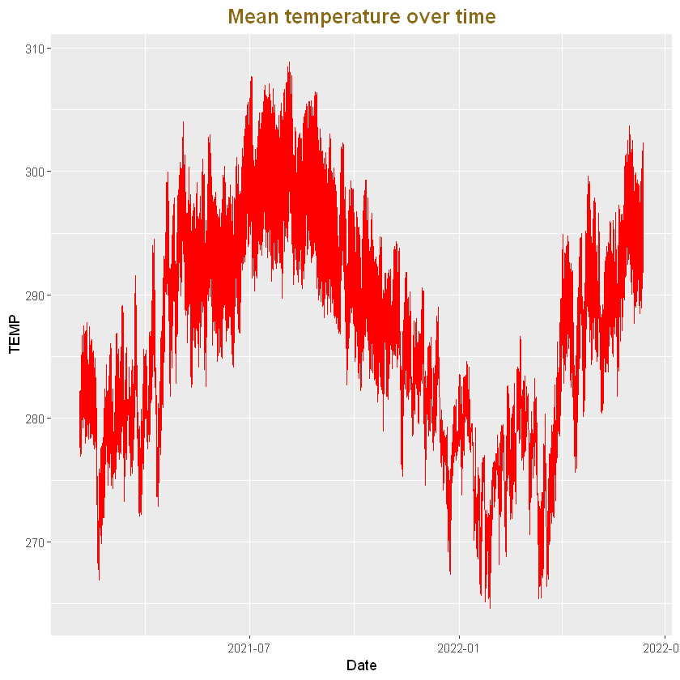

```r
ggplot(dt, aes(x=datetime)) + geom_line(aes(y=TEMP), color="red")+
 labs(title = "Mean temperature over time", x = "Date",y = "TEMP")+
  theme(plot.title = element_text(color = "goldenrod4", size = 15, face = "bold",hjust=0.5),
  plot.subtitle = element_text(size = 7,color="goldenrod3", face = "bold", hjust = 0.5))
```

### Production Plot

#### Production values from February 1 2021 to current date is plotted.

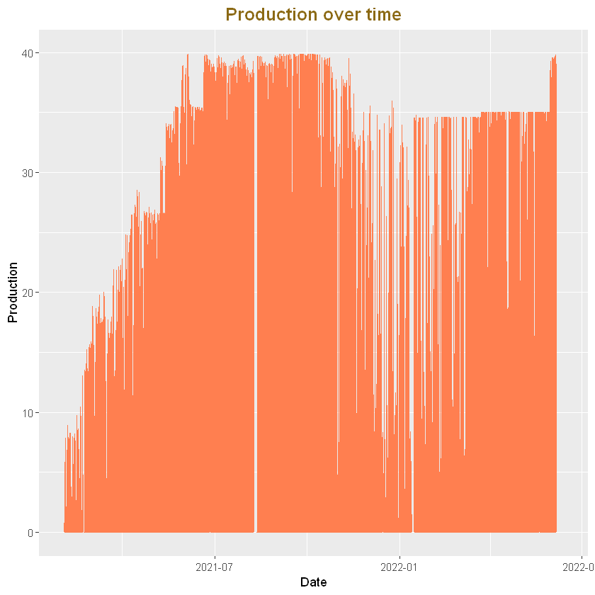

```r
ggplot(dt, aes(x=datetime)) + geom_line(aes(y=production), color="coral")+
 labs(title = "Production over time", x = "Date",y = "Production")+
  theme(plot.title = element_text(color = "goldenrod4", size = 15, face = "bold",hjust=0.5),
  plot.subtitle = element_text(size = 7,color="goldenrod3", face = "bold", hjust = 0.5))
```

### Production Capacities

#### One could easily observe that max production for each month tends to increase up until June 2021. This could result from the progressive increase in the capacity of the power plant. After June, capacity is not changed for a while, and it is pulled down at the beginning of 2022. We will ignore the timeline in which capacities are increased; instead, data from June 2021 will be used for convenience.

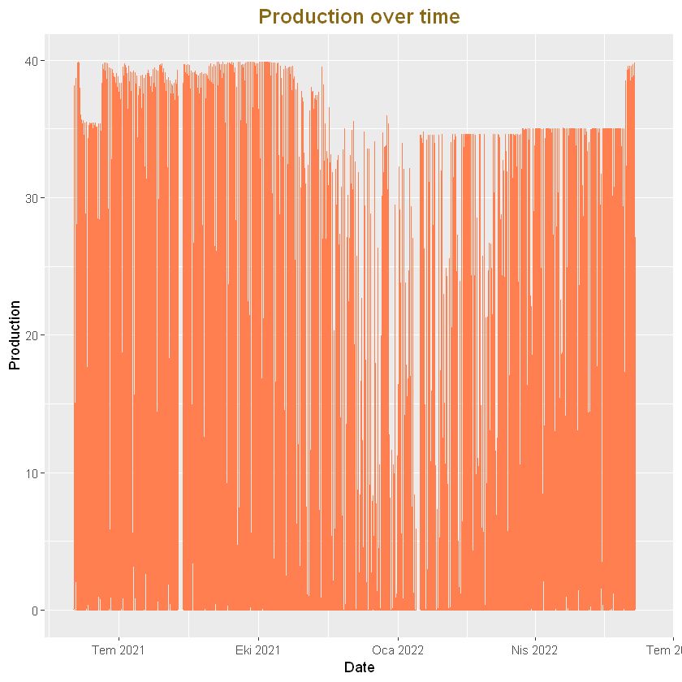

```r
dt <- dt[datetime > "2021-06-01"]

ggplot(dt, aes(x=datetime)) + geom_line(aes(y=production), color="coral")+
 labs(title = "Production over time", x = "Date",y = "Production")+
  theme(plot.title = element_text(color = "goldenrod4", size = 15, face = "bold",hjust=0.5),
  plot.subtitle = element_text(size = 7,color="goldenrod3", face = "bold", hjust = 0.5))
```

### Autocorrelation for Production

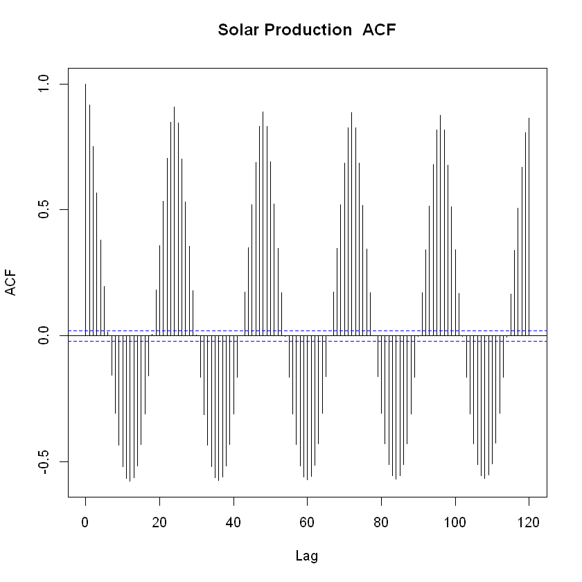

```r
AutoCorrelation <- acf(dt$production, lag.max = 120,plot = FALSE, na.action = na.pass)

plot(AutoCorrelation, main = "Solar Production  ACF")
```

#### Daily seasonality for the production data is easily observed. Production volume at hour h in the last day and production at hour h in the previous days are correlated. Therefore, the effects of each variable might differ considerably for different production hours. Our approach here is to divide the production data into 24 hours and make predictions for each hourly data for the next day. Thus, at the end, there will be 24 different models at best, given that there are distinct models for each hour. However, further examination is required before any action towards modeling is taken.

### Correlation plot between weather variables

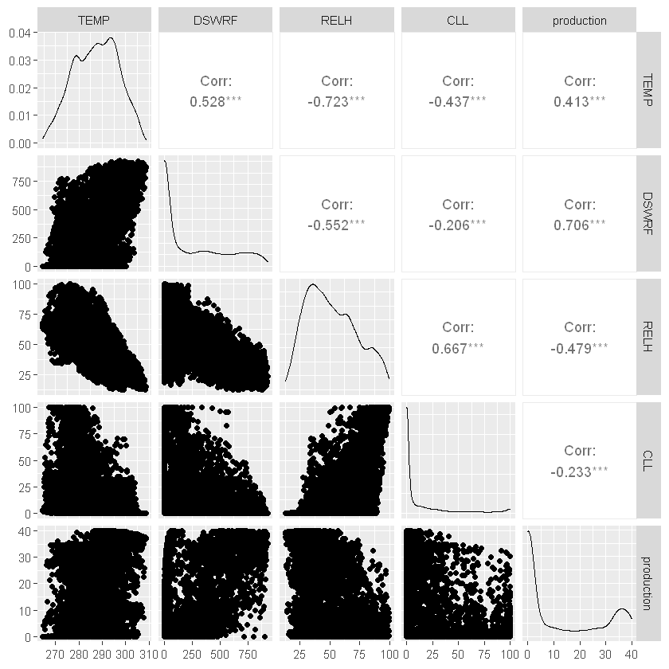

```r
ggpairs(dt[, c("TEMP", "DSWRF", "RELH", "CLL", "production")])
```

### Cutting thresholds for weather variables

#### By analyzing the ggpair plot, it is observed that production and weather data are not strictly correlated in a linear fashion. Instead there are certain thresholds before/after practical patterns are to be observed. We will use additional variables in order to explain these behaviours. DSWRF variable seems to maximize the production after its numerical value pass 300, thus a variable named DSWRF_above is introduced. Further, temperature maximizes the production after its numerical value pass 302. TEMP_above is introduced at this point. In a similar manner, RELH_above and CLL_above are introduced as well.

#### We had tried using dummy variables, but they didn't catch the difference from border points, so we used additional variables instead of dummy variables.

```r
dt[, DSWRF_above := ifelse(DSWRF > 300, DSWRF, 0)]

dt[, TEMP_above := ifelse(TEMP > 302, TEMP, 0)]

dt[, RELH_above := ifelse(RELH > 75, RELH, 0)]

dt[, CLL_above := ifelse(CLL > 40, CLL, 0)]
```

```r
dt[, CLL_lag1 := shift(CLL)]
dt[, RELH_lag1 := shift(RELH)]
dt[, DSWRF_lag1 := shift(DSWRF)]
dt[, TEMP_lag1 := shift(TEMP)]

dt[, CLL_lag2 := shift(CLL_lag1)]
dt[, RELH_lag2 := shift(RELH_lag1)]
dt[, DSWRF_lag2 := shift(DSWRF_lag1)]
dt[, TEMP_lag2 := shift(TEMP_lag1)]

dt[, CLL_lag3 := shift(CLL_lag2)]
dt[, RELH_lag3 := shift(RELH_lag2)]
dt[, DSWRF_lag3 := shift(DSWRF_lag2)]
dt[, TEMP_lag3 := shift(TEMP_lag2)]

dt[, CLL_lag4 := shift(CLL_lag3)]
dt[, RELH_lag4 := shift(RELH_lag3)]
dt[, DSWRF_lag4 := shift(DSWRF_lag3)]
dt[, TEMP_lag4 := shift(TEMP_lag3)]

dt[, CLL_next1 := shift(CLL, -1)]
dt[, RELH_next1 := shift(RELH, -1)]
dt[, DSWRF_next1 := shift(DSWRF, -1)]
dt[, TEMP_next1 := shift(TEMP, -1)]

dt[, CLL_next2 := shift(CLL, -2)]
dt[, RELH_next2 := shift(RELH, -2)]
dt[, DSWRF_next2 := shift(DSWRF, -2)]
dt[, TEMP_next2 := shift(TEMP, -2)]

dt[, CLL_next3 := shift(CLL, -3)]
dt[, RELH_next3 := shift(RELH, -3)]
dt[, DSWRF_next3 := shift(DSWRF, -3)]
dt[, TEMP_next3 := shift(TEMP, -3)]

dt[, CLL_mean11 := frollmean(CLL, 11, align="center", na.rm=T)]
dt[, RELH_mean11 := frollmean(RELH, 11, align="center", na.rm=T)]
dt[, RELH_l8h := frollmean(RELH, 8, align="right", na.rm=T)]
```

### Maximum productions

```r
for (h in 0:23){
    print(paste("Maximum production at hour ", h, ": ", max(dt[hour == h, production], na.rm = T)))
}

# There is just one day that has nonzero production at hour = 20. So, it can be assumed to be 0 while forecasting.
table(dt[hour == 20, production])
```

```
[1] "Maximum production at hour  0 :  0"
[1] "Maximum production at hour  1 :  0"
[1] "Maximum production at hour  2 :  0"
[1] "Maximum production at hour  3 :  0"
[1] "Maximum production at hour  4 :  0"
[1] "Maximum production at hour  5 :  0.251"
[1] "Maximum production at hour  6 :  7.97"
[1] "Maximum production at hour  7 :  27.84"
[1] "Maximum production at hour  8 :  39.62"
[1] "Maximum production at hour  9 :  39.878723"
[1] "Maximum production at hour  10 :  39.878"
[1] "Maximum production at hour  11 :  39.878"
[1] "Maximum production at hour  12 :  39.847"
[1] "Maximum production at hour  13 :  39.88"
[1] "Maximum production at hour  14 :  39.847"
[1] "Maximum production at hour  15 :  39.72"
[1] "Maximum production at hour  16 :  39.217"
[1] "Maximum production at hour  17 :  29.419"
[1] "Maximum production at hour  18 :  12.19"
[1] "Maximum production at hour  19 :  2.173"
[1] "Maximum production at hour  20 :  0.15"
[1] "Maximum production at hour  21 :  0"
[1] "Maximum production at hour  22 :  0"
[1] "Maximum production at hour  23 :  0"
```

```
   0 0.15
 364    1
```

#### As was observed in the production plots, the plant operates by changing its capacity throughout the seasons. In order to use production volumes of different date times when capacities are non-constant, we will scale the production volumes. The most sensible way to scale these numerical values is to divide them by the capacity of the product at the given time. Capacity determination is another issue here. Our approach to the capacity is to consider the maximum production of a time window of predetermined size as the capacity of the plant within that time window. The Time window size is one month (30 days) for convenience.

#### In addition, the data frame is divided into hours so that distinct models can be constructed for each hour. Here, lagged production volumes (scaled) are introduced as well. lag72 stands for the scaled production three days before, and each 24 hours increment depicts one day lag. lag24 and lag48 cannot be used since prediction for d+1 is made by the past production data up until the end of day d-2.

```r
dt_hour <- list()
for (h in 5:19){
    dt_hour[[h]] <- dt[hour == h]
    dt_hour[[h]][, capacity := frollapply(production, 30, FUN="max", align="right", na.rm=T)]
    dt_hour[[h]][, scaledprod := production/capacity]
    dt_hour[[h]][, scaledprod_lag72 := shift(scaledprod, 3)]
    dt_hour[[h]][, scaledprod_lag96 := shift(scaledprod, 4)]
    dt_hour[[h]][, scaledprod_lag120 := shift(scaledprod, 5)]
}
```

#### Plotting for 12 pm

Correlation plots are constructed for weather related variables once again. This time only for hour 12 pm.

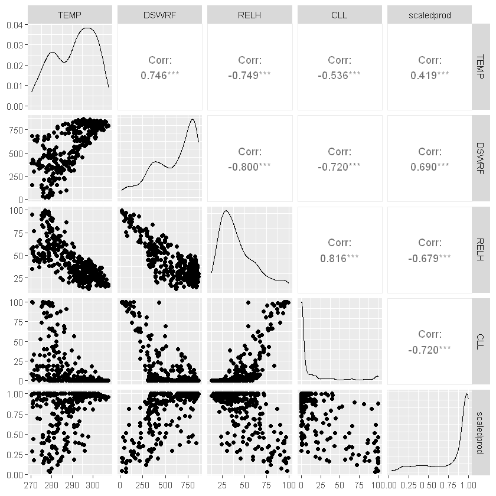

```r
ggpairs(dt_hour[[12]][, c("TEMP", "DSWRF", "RELH", "CLL", "scaledprod")])
```

### Behaviours explained above for the whole data are observed more clearly in this plot.

### To have a better understanding, productions are analyzed in a timely manner. As it can be seen on the moving average table, productions aren't stationary. This information might be helpful in constructing Arima and Sarima models

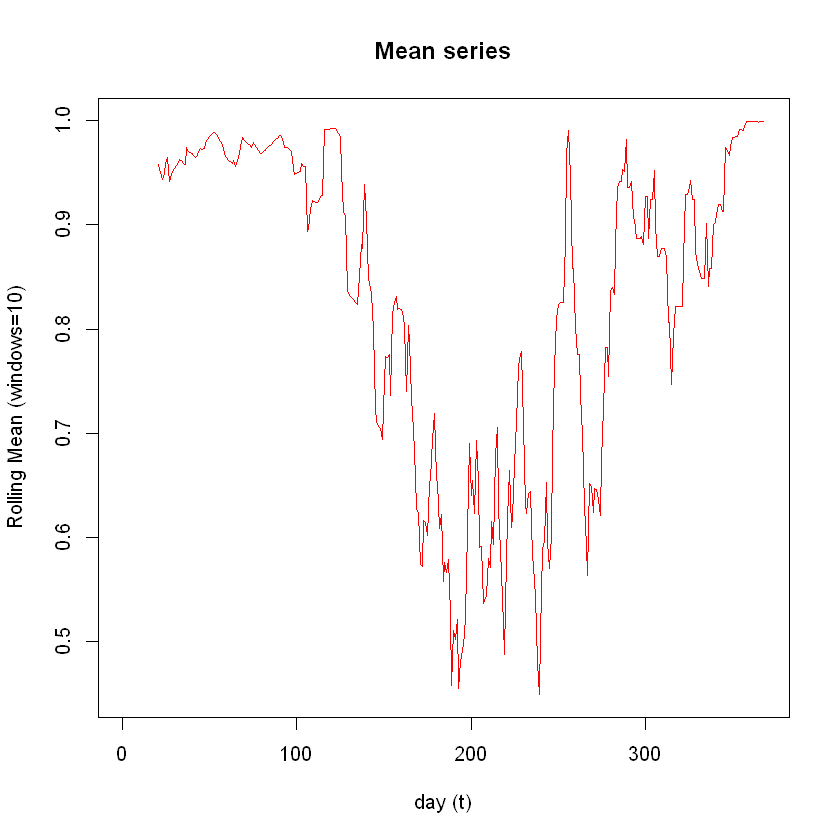

```r
time_window=10
mean_series=rollmean(dt_hour[[12]]$scaledprod,time_window,align='left',na.rm= TRUE )


plot(mean_series,
     type='l',col='red',
     xlab = "day (t)",
     ylab = "Rolling Mean (windows=10)",
     main = "Mean series")
```